# How to use FactorAssumptions

Jose Eduardo Storopoli

7/16/2019

# FactorAssumptions

Set of Assumptions for Factor and Principal Component Analysis

Description:Tests for Kaiser-Meyer-Olkin (KMO) and communalities in a dataset. It provides a final sample by removing variables in a iterable manner while keeping account of the variables that were removed in each step.

## What is KMO and Communalities?

*Factor Analysis* and *Principal Components Analysis* (PCA) have some precautions and assumptions to be observed (Hair et al. (2018)).

The first one is the KMO (Kaiser-Meyer-Olkin) measure, which measures the proportion of variance among the variables that can be derived from the common variance, also called systematic variance. KMO is computed between 0 and 1. Low values (close to 0) indicate that there are large partial correlations in comparison to the sum of the correlations, that is, there is a predominance of correlations of the variables that are problematic for the factorial/principal component analysis. Hair et al. (2018) suggest that individual KMOs smaller than 0.5 be removed from the factorial/principal component analysis. Consequently, this removal causes the overall KMO of the remaining variables of the factor/principal component analysis to be greater than 0.5.

The second assumption of a valid factor or PCA analysis is the communality of the rotated variables. The commonalities indicate the common variance shared by factors/components with certain variables. Greater communality indicated that a greater amount of variance in the variable was extracted by the factorial/principal component solution. For a better measurement of factorial/principal component analysis, communalities should be 0.5 or greater (Hair et al. (2018)).

## Loading an example dataset

First we will load an example dataset `bfi` from `psych` and load the package `FactorAssumptions`

```r
library(FactorAssumptions, quietly = T, verbose = F)
bfi_data <- bfi
#Remove rows with missing values and keep only complete cases
bfi_data <- bfi_data[complete.cases(bfi_data),]
head(bfi_data)
```

```
##       A1 A2 A3 A4 A5 C1 C2 C3 C4 C5 E1 E2 E3 E4 E5 N1 N2 N3 N4 N5 O1 O2 O3
## 61623  6  6  5  6  5  6  6  6  1  3  2  1  6  5  6  3  5  2  2  3  4  3  5
## 61629  4  3  1  5  1  3  2  4  2  4  3  6  4  2  1  6  3  2  6  4  3  2  4
## 61634  4  4  5  6  5  4  3  5  3  2  1  3  2  5  4  3  3  4  2  3  5  3  5
## 61640  4  5  2  2  1  5  5  5  2  2  3  4  3  6  5  2  4  2  2  3  5  2  5
## 61661  1  5  6  5  6  4  3  2  4  5  2  1  2  5  2  2  2  2  2  2  6  1  5
## 61664  2  6  5  6  5  3  5  6  3  6  2  2  4  6  6  4  4  4  6  6  6  1  5
##       O4 O5 gender education age
## 61623  6  1      2         3  21
## 61629  5  3      1         2  19
## 61634  6  3      1         1  21
## 61640  5  5      1         1  17
## 61661  5  2      1         5  68
## 61664  6  1      2         2  27
```

## How many factors?

This is a frequent question. You can use the **Parallel Analysis**. The logic underlying this approach is that the magnitude of the eigenvalue for the last retained factor should exceed an eigenvalue obtained from random data under otherwise comparable conditions. In other words, in a real study involving the factor analysis of, say, 20 variables measured on 500 people, the eigenvalue of any retained factor should be greater than the corresponding eigenvalue obtained from randomly generated data arranged to represent 20 variables measured on 500 people. We generally use a representative value (e.g., the 95% percentile).

```
## Parallel Analysis (n = 7)
```

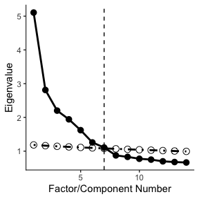

```r
screePlotAPA(bfi_data, rep=1000, quantile=.05, model = "components")
```

## Performing the KMO Assumptions

First we will perform the $KMO > 0.5 assumption$ for all individuals variables in the dataset with the `kmo_optimal_solution` function

```r
kmo_bfi <- kmo_optimal_solution(bfi_data, squared = FALSE)
```

```
## Final Solution Achieved!
```

Note that the `kmo_optimal_solution` outputs a list:

1. the final solution as `df`
2. removed variables with $invidual KMO < 0.5$ as `removed`
3. Anti-image covariance matrix as `AIS`
4. Anti-image correlation matrix as `AIR`

In our case none of the variables were removed due to low individual KMO values

```r
kmo_bfi$removed
```

[output not shown]

## Performing the Communalities Assumptions

The parallel analysis of `bfi` data suggests seven factors we will then perform the assumptions for all $individual communalities > 0.5$ with the argument `nfactors` set to 7.

We can use either the values `principal` or `fa` functions from `psych` package for argument `type` as desired:

- `principal` will perform a *Principal Component Analysis* (PCA)
- `fa` will perform a *Factor Analysis*

*Note*: we are using the `df` generated from the `kmo_optimal_solution` function *Note 2*: the default of rotation employed by the `communalities_optimal_solution` is `varimax`. You can change if you want.

```r
comm_bfi <- communalities_optimal_solution(kmo_bfi$df, type = "principal", nfactors = 7, squared = FALSE)
```

```
## There is still an individual communality value below 0.5: A4 - 0.423382853387628
```

```
## There is still an individual communality value below 0.5: O4 - 0.473944505255499
```

```
## There is still an individual communality value below 0.5: C1 - 0.494613330049183
```

```
##
## Loadings:
##           RC2    RC1    RC5    RC4    RC3    RC6    RC7
## N1         0.825
## N2         0.820
## N3         0.794
## N4         0.626 -0.421
## N5         0.611
## E1               -0.735
## E2               -0.747
## E3                0.512  0.430
## E4                0.638  0.409
## E5                0.573
## A1                      -0.509                0.456
## A2                       0.690
## A3                       0.749
## A5                       0.674
## C2                              0.722
## C3                              0.715
## C4                             -0.697
## C5                             -0.667
## O2                                     0.721
## O3                                    -0.572
## O5                                     0.762
## gender                                       -0.660
## education                                            0.767
## age                                                  0.769
## O1                                    -0.473  0.487
##
##                  RC2   RC1   RC5   RC4   RC3   RC6   RC7
## SS loadings    3.093 2.693 2.466 2.232 1.902 1.380 1.323
## Proportion Var 0.124 0.108 0.099 0.089 0.076 0.055 0.053
## Cumulative Var 0.124 0.231 0.330 0.419 0.495 0.551 0.604
```

[figure not shown]

[figure not shown]

Note that the `communalities_optimal_solution` outputs a list:

1. the final solution as `df`
2. removed variables with $invidual communalities < 0.5$ as `removed`
3. A table with the communalities loadings from the variables final iteration as `loadings`
4. Results of the final iteration of either the `principal` or `fa` functions from `psych` package as `results`

In our case 3 variables were removed in an iterable fashion due to low individual communality values. And they are listed from the lowest communality that were removed until rendered an optimal solution.

```r
comm_bfi$removed
```

```
## [1] "A4" "O4" "C1"
```

And finally we arrive at our final principal components analysis rotated matrix. You can export it as a CSV with `write.csv` or `write.csv2`

```r
comm_bfi$results
```

```
## Principal Components Analysis
## Call: principal(r = df, nfactors = nfactors, scores = T)
## Standardized loadings (pattern matrix) based upon correlation matrix
##             RC2   RC1   RC5   RC4   RC3   RC6   RC7   h2   u2 com
## A1         0.13  0.13 -0.51  0.09  0.22  0.46 -0.22 0.60 0.40 3.2
## A2         0.03  0.15  0.69  0.14 -0.05 -0.21  0.08 0.57 0.43 1.4
## A3        -0.02  0.21  0.75  0.11  0.01  0.00 -0.02 0.62 0.38 1.2
## A5        -0.17  0.30  0.67  0.07  0.05  0.09  0.02 0.59 0.41 1.6
## C2         0.11 -0.04  0.17  0.72 -0.08  0.14 -0.05 0.59 0.41 1.3
## C3        -0.02 -0.01  0.13  0.72  0.08  0.06  0.09 0.55 0.45 1.1
## C4         0.22 -0.13  0.04 -0.70  0.22  0.22 -0.06 0.66 0.34 1.8
## C5         0.29 -0.21  0.01 -0.67  0.03  0.12  0.06 0.59 0.41 1.7
## E1        -0.01 -0.74 -0.12  0.10  0.13  0.22  0.00 0.63 0.37 1.3
## E2         0.22 -0.75 -0.16 -0.07  0.06  0.02 -0.06 0.65 0.35 1.3
## E3         0.03  0.51  0.43  0.09 -0.18  0.31 -0.09 0.59 0.41 3.1
## E4        -0.15  0.64  0.41  0.07  0.15  0.07 -0.10 0.64 0.36 2.1
## E5         0.09  0.57  0.17  0.34 -0.14  0.16  0.15 0.55 0.45 2.5
## N1         0.83  0.09 -0.18 -0.05  0.08  0.03  0.01 0.73 0.27 1.1
## N2         0.82  0.07 -0.17 -0.03  0.00 -0.04  0.00 0.71 0.29 1.1
## N3         0.79 -0.07  0.01 -0.07  0.01 -0.03 -0.07 0.65 0.35 1.1
## N4         0.63 -0.42  0.04 -0.18 -0.03  0.09  0.06 0.62 0.38 2.0
## N5         0.61 -0.20  0.15 -0.03  0.17 -0.20 -0.12 0.52 0.48 1.9
## O1         0.01  0.15  0.19  0.12 -0.47  0.49  0.03 0.54 0.46 2.6
## O2         0.15 -0.02  0.12 -0.08  0.72  0.04 -0.03 0.57 0.43 1.2
## O3         0.06  0.26  0.27  0.04 -0.57  0.34  0.02 0.59 0.41 2.7
## O5         0.04 -0.01 -0.02 -0.02  0.76  0.05 -0.03 0.59 0.41 1.0
## gender     0.19  0.16  0.19  0.11  0.01 -0.66 -0.02 0.55 0.45 1.5
## education  0.00 -0.03  0.04 -0.01 -0.07  0.06  0.77 0.60 0.40 1.0
## age       -0.08  0.06  0.03  0.06 -0.01 -0.08  0.77 0.61 0.39 1.1
##
##                        RC2  RC1  RC5  RC4  RC3  RC6  RC7
## SS loadings           3.09 2.69 2.47 2.23 1.90 1.38 1.32
## Proportion Var        0.12 0.11 0.10 0.09 0.08 0.06 0.05
## Cumulative Var        0.12 0.23 0.33 0.42 0.50 0.55 0.60
## Proportion Explained  0.20 0.18 0.16 0.15 0.13 0.09 0.09
## Cumulative Proportion 0.20 0.38 0.55 0.69 0.82 0.91 1.00
##
## Mean item complexity =  1.7
## Test of the hypothesis that 7 components are sufficient.
##
## The root mean square of the residuals (RMSR) is  0.06
##  with the empirical chi square  4194.08  with prob <  0
##
## Fit based upon off diagonal values = 0.92
```

# References

Hair, Joseph F., William C. Black, Barry J. Babin, and Rolph E. Anderson. 2018. *Multivariate Data Analysis*. 8th ed. Cengage Learning.